# Customers RFM Clustering (Market Segmentation based on Behavioral Approach)

## 7.2 Optimal number of clusters (Hierarchical K-Means):

### 7.2.1 Elbow method:

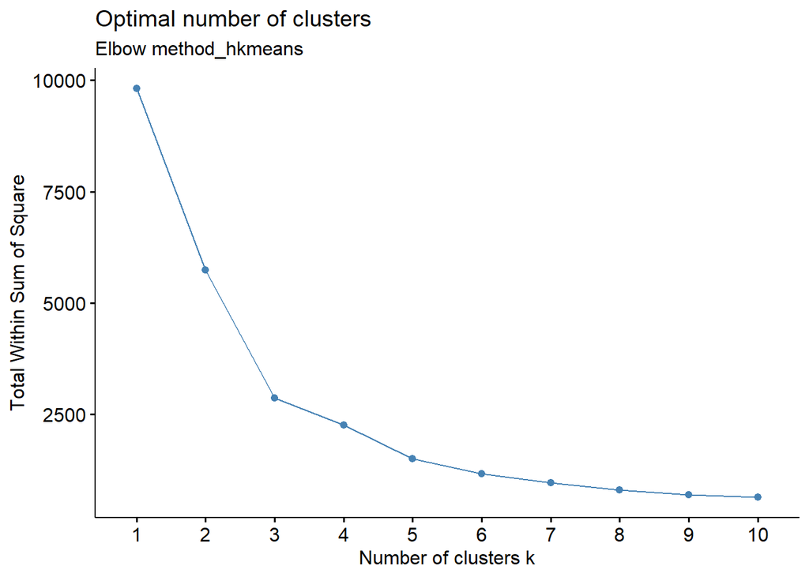

```r
plot_elbow_hk <- factoextra::fviz_nbclust(rfm_customer_2_sample, hkmeans, method = 'wss') +
            labs(subtitle = 'Elbow method_hkmeans')
plot_elbow_hk
```

```r
plot_elbow_hk$data
```

| clusters | y |
| --- | --- |
| 1 | 9811.1765 |
| 2 | 5746.9011 |
| 3 | 2872.3106 |
| 4 | 2262.3910 |
| 5 | 1505.4725 |
| 6 | 1162.0851 |
| 7 | 967.6200 |
| 8 | 809.8985 |
| 9 | 695.7626 |
| 10 | 639.4019 |

### 7.2.2 Silhouette method:

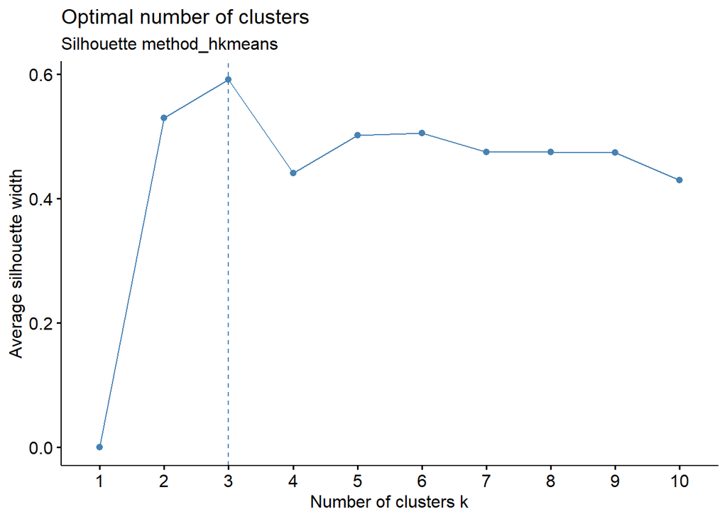

```r
plot_silhouette_hk <- factoextra::fviz_nbclust(rfm_customer_2_sample, hkmeans, method = 'silhouette') +
            labs(subtitle = 'Silhouette method_hkmeans')
plot_silhouette_hk
```

```r
plot_silhouette_hk$data
```

| clusters | y |
| --- | --- |
| 1 | 0.0000000 |
| 2 | 0.5303346 |
| 3 | 0.5914331 |
| 4 | 0.4409877 |
| 5 | 0.5024371 |
| 6 | 0.5052502 |
| 7 | 0.4748674 |
| 8 | 0.4754031 |
| 9 | 0.4747014 |
| 10 | 0.4299384 |

> Now, we can compare models based on their silhouette (max) and twss (min) index -> based-on statistical indexes, hklust results is better than others

But there is still a question: are these Clusters good from Business aspect? which Clustering results are better? -> we can not answer this question in ML area, we can answer this question in applied area

For more information check the [Github](https://github.com/mamomen1996/R_CS_09) repository.